# A study of wage inequality between men and women

# Introduction

Men and women suffer inequality of wage. Studies show an income difference from 18% to 25%. Doing this study, i want to understand what are the causes of those inequalities, if there is a mean to detect it solve it. We will also try to predict salary income using data, this lead to a more fair salary.

# Some preprocessing in the data

## load packages

```r
#load the packages
library(eurostat)
library(tidyverse)
library(rmdformats)
require(maps)
require(viridis)
library(tidyverse)
library(dplyr)
library(plotly)
library(ggplot2)
library(ggmap)
library(maptools)
library(mapdata)
library(data.table)
```

## Get the Table of Content (TOC) of Eurostat data

```r
toc <- get_eurostat_toc()
```

## get some data

```r
d_list_wage <- get_eurostat('earn_ses06_20') #Salary by economic activity, age and sex
```

```
## Table earn_ses06_20 cached at C:\Users\samyd\AppData\Local\Temp\RtmpwPIeu2/eurostat/earn_ses06_20_date_code_TF.rds
```

## Cast the list into a R dataframe

```r
df_wage <- as.data.frame(d_list_wage)
```

# plotting the total wage of men and women for europe

We want to verify if the number we found is similar to the medias number. We still have to remember that our mean will be a population sample and is biased.

## selecting the interesting data

```r
data_wage_male <- subset(df_wage, df_wage$age == "TOTAL" & df_wage$geo =="EU27" & unit == "EUR" & df_wage$indic_se == "ME" & ( df_wage$sex =="M" ),  select=c(unit,age, indic_se,sex,geo,values,time))
data_wage_female <- subset(df_wage, df_wage$age == "TOTAL" & df_wage$geo =="EU27" & unit == "EUR" & df_wage$indic_se == "ME" & (  df_wage$sex =="F"),  select=c(unit,age, indic_se,sex,geo,values,time))
```

```r
data_mean_salary_men_women <- data.frame(salary = c(men_avg_wage=mean(data_wage_male$values), women_avg_wage=mean(data_wage_female$values)),sex =c("H","F"))
```

## Calculate the value difference in percentage

```r
difference_in_percentage <- (data_mean_salary_men_women$men_avg_wage - data_mean_salary_men_women$women_avg_wage)/data_mean_salary_men_women$men_avg_wage
```

## plotting it to an histogram

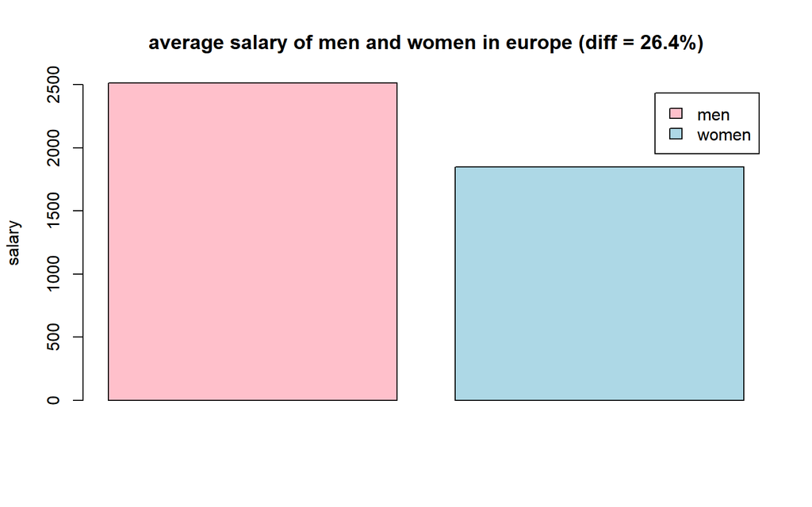

```r
barplot(data_mean_salary_men_women$salary, main = "average salary of men and women in europe (diff = 26.4%)", ylab = "salary",legend.text = c("men","women"),col=c("pink","light blue"))
```

# evolution of male and female income by year

we now want to see how male and female wages has evolved during the last few year

## import data per time

```r
d_list_wage_per_date <- get_eurostat('tps00175') #Salary by sex and time
```

```
## Table tps00175 cached at C:\Users\samyd\AppData\Local\Temp\RtmpwPIeu2/eurostat/tps00175_date_code_TF.rds
```

## selecting the interesting data

```r
average_salary_per_year <- aggregate(values~sex+time, data=d_list_wage_per_date, FUN=sum)
```

## Plotting the data

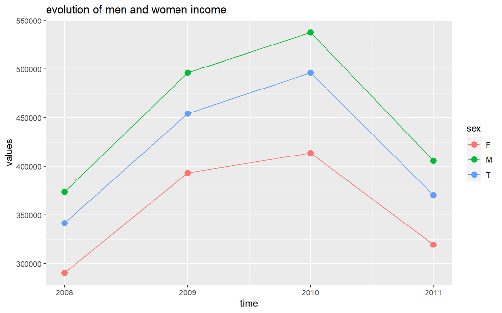

```r
gp <- ggplot(data = average_salary_per_year, aes(x = time, y = values, colour = sex))
gp + geom_point(size = 3) + geom_line() + ggtitle("evolution of men and women income")
```

# evolution of income difference by year

we want to see if the income difference has increase or descreased the last few yaer and do an analysis out of this

## importing data of difference income by year

```r
d_list_income_difference <- get_eurostat('sdg_05_20') #Salary by sex and time
```

```
## Table sdg_05_20 cached at C:\Users\samyd\AppData\Local\Temp\RtmpwPIeu2/eurostat/sdg_05_20_date_code_TF.rds
```

## processing data

```r
d_list_income_difference_europe <-  subset(d_list_income_difference, d_list_income_difference$geo == "EU27",  select=c(time,values)) #income difference evolution between men and women
```

## plotting the graph

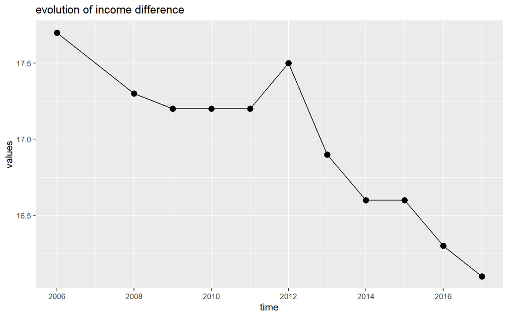

```r
gp <- ggplot(data = d_list_income_difference_europe, aes(x = time, y = values))
gp + geom_point(size = 3) + geom_line() + ggtitle("evolution of income difference")
```

# Plotting the map of salary difference in percentage

We now have to remember that even if Europe Union can be seen as a singel entity, some european countries are wealthier than others. And we also has to figure out that the minimum salary isn’t the same in all european union.

## adding the country code

```r
countryCode = c("BE","BG","CZ","DK","DE","EE","IE","EL","ES","FR","HR","IT","CY","LV","LT","LU","HU","MT","NL","AT","PL","PT","RO","SI","SK","FI","UK","SE")
```

## preprocessing the data

```r
Salary_difference <- subset(d_list_income_difference, d_list_income_difference$time != "2002-01-01" & d_list_income_difference$geo != "EU27" & d_list_income_difference$geo !="EU28" & d_list_income_difference$geo !="EA19" & d_list_income_difference$geo !="ME" & d_list_income_difference$geo !="MK" & d_list_income_difference$geo !="RS" & d_list_income_difference$geo !="TR")
result_salary_difference_mean <- aggregate(values~geo, data=Salary_difference, FUN =mean)

result_salary_difference_mean$region <-c("Bulgaria","Cyprus","Czechia","Greece","Spain","Hungary","Ireland","Lithuania","Netherlands","Poland","Romania","Slovenia","Slovakia","UK","Austria","Belgium","Switzerland","Germany","Denmark","Estonia","Finland","France","Italy","Luxembourg","Latvia","Malta","Norway","Portugal","Sweden","Iceland","Croatia")

result_salary_difference_mean$roundedvalues <- round(result_salary_difference_mean$values, digits=2)

some_eu_countries_salary <-c("Bulgaria","Cyprus","Czechia","Greece","Spain","Hungary","Ireland","Lithuania","Netherlands","Poland","Romania","Slovenia","Slovakia","UK","Austria","Belgium","Switzerland","Germany","Denmark","Estonia","Finland","France","Italy","Luxembourg","Latvia","Malta","Norway","Portugal","Sweden","Iceland","Croatia")
```

## plotting the map

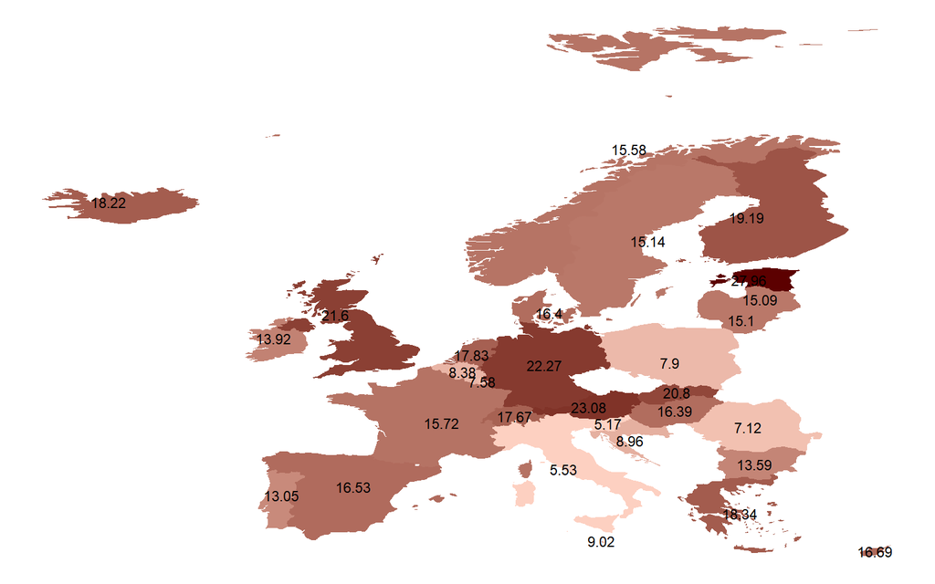

```r
# Retrievethe map data
eu.map <- map_data("world", region = some_eu_countries_salary)
# Compute the centroid as the mean longitude and lattitude
# Used as label coordinate for country's names
region.lab.data <- eu.map %>%
  group_by(region) %>%
  summarise(long = mean(long), lat = mean(lat))

salary.difference.map <- left_join(result_salary_difference_mean, eu.map, by = "region")

salary.difference.data <- salary.difference.map %>%
  group_by(region) %>%
  summarise(long = mean(long), lat = mean(lat), values=mean(as.numeric(as.character(roundedvalues))))

ggplot(salary.difference.map, aes(x = long, y = lat)) +
  geom_polygon(aes( group = group, fill = values))+
  geom_text(aes(label = values), data = salary.difference.data,  size = 3, hjust = 0.5)+
  scale_fill_gradient(low = "#ffd3c4", high = "#5c0000")+
  theme_void()+
  theme(legend.position = "none")
```